# MTH6139 Time Series

Coursework 1

Bulat Makhmutov

March 2026

# Introduction

This project explores the built-in `co2` time series in R. The main aim is to study the behaviour of the series and produce a forecast using Meta’s Prophet model.

I chose this dataset because it is simple to use and it shows clear time series patterns. In particular, it has both a long-term trend and a seasonal pattern, so it is a suitable example for forecasting.

# Data Description

The `co2` dataset contains monthly atmospheric CO2 measurements. It is a classic example in R and is often used to illustrate time series methods.

Before fitting a Prophet model, the data must be converted into a dataframe with two columns: - `ds` for the date - `y` for the observed value

# Loading libraries and preparing the data

```r
library(prophet)
library(zoo)
```

```r
library(ggplot2)
library(dplyr)
data("co2")

co2_dataframe <- data.frame(
  ds = as.Date(as.yearmon(time(co2))),
  y = as.numeric(co2)
)
```

# Checking the data

```r
head(co2_dataframe)
```

```
##           ds      y
## 1 1959-01-01 315.42
## 2 1959-02-01 316.31
## 3 1959-03-01 316.50
## 4 1959-04-01 317.56
## 5 1959-05-01 318.13
## 6 1959-06-01 318.00
```

```r
str(co2_dataframe)
```

```
## 'data.frame':    468 obs. of  2 variables:
##  $ ds: Date, format: "1959-01-01" "1959-02-01" ...
##  $ y : num  315 316 316 318 318 ...
```

```r
summary(co2_dataframe)
```

```
##        ds                   y
##  Min.   :1959-01-01   Min.   :313.2
##  1st Qu.:1968-09-23   1st Qu.:323.5
##  Median :1978-06-16   Median :335.2
##  Mean   :1978-06-16   Mean   :337.1
##  3rd Qu.:1988-03-08   3rd Qu.:350.3
##  Max.   :1997-12-01   Max.   :366.8
```

```r
sum(is.na(co2_dataframe))
```

```
## [1] 0
```

The data appears clean and there are no missing values.

# Exploratory Analysis

I first plot the time series to understand its shape.

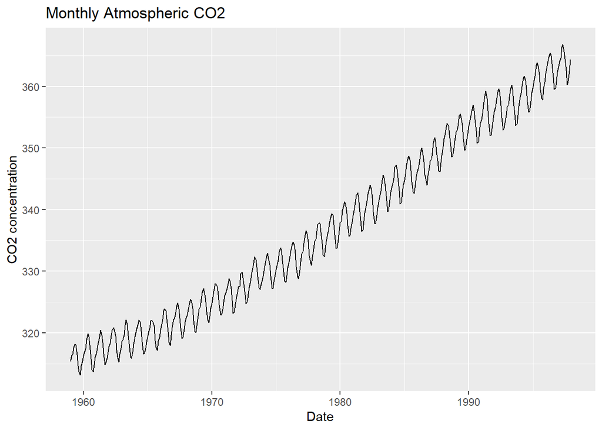

```r
ggplot(co2_dataframe, aes(x = ds, y = y)) +
  geom_line() +
  labs(
    title = "Monthly Atmospheric CO2",
    x = "Date",
    y = "CO2 concentration"
  )
```

The graph shows a clear upward trend over time. There is also a repeated seasonal pattern across the years. This means the series has both long-run growth and regular within-year variation.

# Simple Trend Check

To support the visual impression of growth, I fit a simple linear regression using a time index.

```r
co2_dataframe$time_index <- 1:nrow(co2_dataframe)

trend_model <- lm(y ~ time_index, data = co2_dataframe)
summary(trend_model)
```

```
##
## Call:
## lm(formula = y ~ time_index, data = co2_dataframe)
##
## Residuals:
##     Min      1Q  Median      3Q     Max
## -6.0399 -1.9476 -0.0017  1.9113  6.5149
##
## Coefficients:
##              Estimate Std. Error t value Pr(>|t|)
## (Intercept) 3.115e+02  2.424e-01  1284.9   <2e-16 ***
## time_index  1.090e-01  8.958e-04   121.6   <2e-16 ***
## ---
## Signif. codes:  0 '***' 0.001 '**' 0.01 '*' 0.05 '.' 0.1 ' ' 1
##
## Residual standard error: 2.618 on 466 degrees of freedom
## Multiple R-squared:  0.9695, Adjusted R-squared:  0.9694
## F-statistic: 1.479e+04 on 1 and 466 DF,  p-value: < 2.2e-16
```

The regression confirms that the series is increasing over time. This is only a simple descriptive check, but it is consistent with the plot above.

# Prophet Model

Next, I fit a Prophet model to the data.

Because the data is monthly, weekly and daily seasonalities are not relevant in this case.

```r
prophet_model <- prophet(
  co2_dataframe,
  weekly.seasonality = FALSE,
  daily.seasonality = FALSE
)
```

Prophet is designed to model trend and seasonality in a flexible way. It is also easy to interpret, which makes it useful for this coursework.

# Forecasting Future Values

I now create future dates and forecast the next 24 months.

```r
future_dates <- make_future_dataframe(
  prophet_model,
  periods = 24,
  freq = "month"
)

forecast_values <- predict(prophet_model, future_dates)
```

# Inspecting the forecast output

```r
head(forecast_values)
```

```
##           ds    trend additive_terms additive_terms_lower additive_terms_upper
## 1 1959-01-01 315.3626     -0.0775880           -0.0775880           -0.0775880
## 2 1959-02-01 315.4469      0.5946394            0.5946394            0.5946394
## 3 1959-03-01 315.5230      1.2325855            1.2325855            1.2325855
## 4 1959-04-01 315.6073      2.4609156            2.4609156            2.4609156
## 5 1959-05-01 315.6888      3.0206586            3.0206586            3.0206586
## 6 1959-06-01 315.7731      2.3515302            2.3515302            2.3515302
##       yearly yearly_lower yearly_upper multiplicative_terms
## 1 -0.0775880   -0.0775880   -0.0775880                    0
## 2  0.5946394    0.5946394    0.5946394                    0
## 3  1.2325855    1.2325855    1.2325855                    0
## 4  2.4609156    2.4609156    2.4609156                    0
## 5  3.0206586    3.0206586    3.0206586                    0
## 6  2.3515302    2.3515302    2.3515302                    0
##   multiplicative_terms_lower multiplicative_terms_upper yhat_lower yhat_upper
## 1                          0                          0   314.7753   315.7671
## 2                          0                          0   315.6022   316.5003
## 3                          0                          0   316.2906   317.2563
## 4                          0                          0   317.5925   318.5389
## 5                          0                          0   318.2384   319.1739
## 6                          0                          0   317.6574   318.5922
##   trend_lower trend_upper     yhat
## 1    315.3626    315.3626 315.2850
## 2    315.4469    315.4469 316.0415
## 3    315.5230    315.5230 316.7556
## 4    315.6073    315.6073 318.0682
## 5    315.6888    315.6888 318.7095
## 6    315.7731    315.7731 318.1247
```

```r
tail(forecast_values)
```

```
##             ds    trend additive_terms additive_terms_lower
## 487 1999-07-01 366.5140      0.7585857            0.7585857
## 488 1999-08-01 366.6340     -1.2398017           -1.2398017
## 489 1999-09-01 366.7540     -3.0557095           -3.0557095
## 490 1999-10-01 366.8702     -3.3646151           -3.3646151
## 491 1999-11-01 366.9902     -2.0907954           -2.0907954
## 492 1999-12-01 367.1064     -0.9763776           -0.9763776
##     additive_terms_upper     yearly yearly_lower yearly_upper
## 487            0.7585857  0.7585857    0.7585857    0.7585857
## 488           -1.2398017 -1.2398017   -1.2398017   -1.2398017
## 489           -3.0557095 -3.0557095   -3.0557095   -3.0557095
## 490           -3.3646151 -3.3646151   -3.3646151   -3.3646151
## 491           -2.0907954 -2.0907954   -2.0907954   -2.0907954
## 492           -0.9763776 -0.9763776   -0.9763776   -0.9763776
##     multiplicative_terms multiplicative_terms_lower multiplicative_terms_upper
## 487                    0                          0                          0
## 488                    0                          0                          0
## 489                    0                          0                          0
## 490                    0                          0                          0
## 491                    0                          0                          0
## 492                    0                          0                          0
##     yhat_lower yhat_upper trend_lower trend_upper     yhat
## 487   366.5581   368.0671    365.9913    367.1191 367.2725
## 488   364.6249   366.1932    366.0588    367.3179 365.3942
## 489   362.9172   364.5722    366.1215    367.4986 363.6983
## 490   362.7072   364.4792    366.1763    367.7000 363.5056
## 491   364.0226   365.9603    366.2303    367.8888 364.8995
## 492   365.2102   367.2016    366.3014    368.0941 366.1300
```

```r
names(forecast_values)
```

```
##  [1] "ds"                         "trend"
##  [3] "additive_terms"             "additive_terms_lower"
##  [5] "additive_terms_upper"       "yearly"
##  [7] "yearly_lower"               "yearly_upper"
##  [9] "multiplicative_terms"       "multiplicative_terms_lower"
## [11] "multiplicative_terms_upper" "yhat_lower"
## [13] "yhat_upper"                 "trend_lower"
## [15] "trend_upper"                "yhat"
```

The forecast object contains many columns, including fitted values and uncertainty intervals.

# Forecast Plot

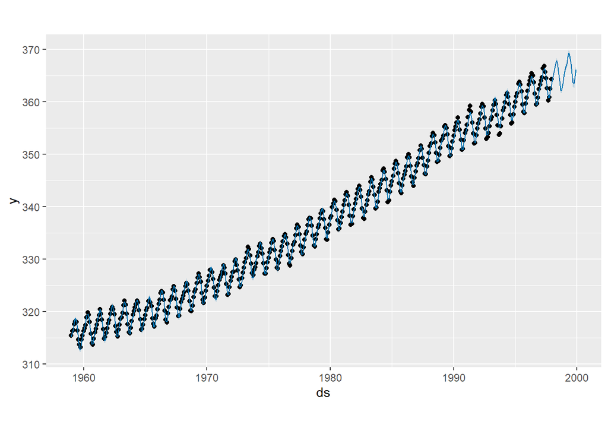

```r
plot(prophet_model, forecast_values)
```

The forecast continues the upward movement seen in the historical data. The seasonal pattern also remains visible in the future period.

This seems reasonable because the original time series shows both steady growth and clear seasonality.

# Model Components

Prophet also allows the components of the model to be plotted separately.

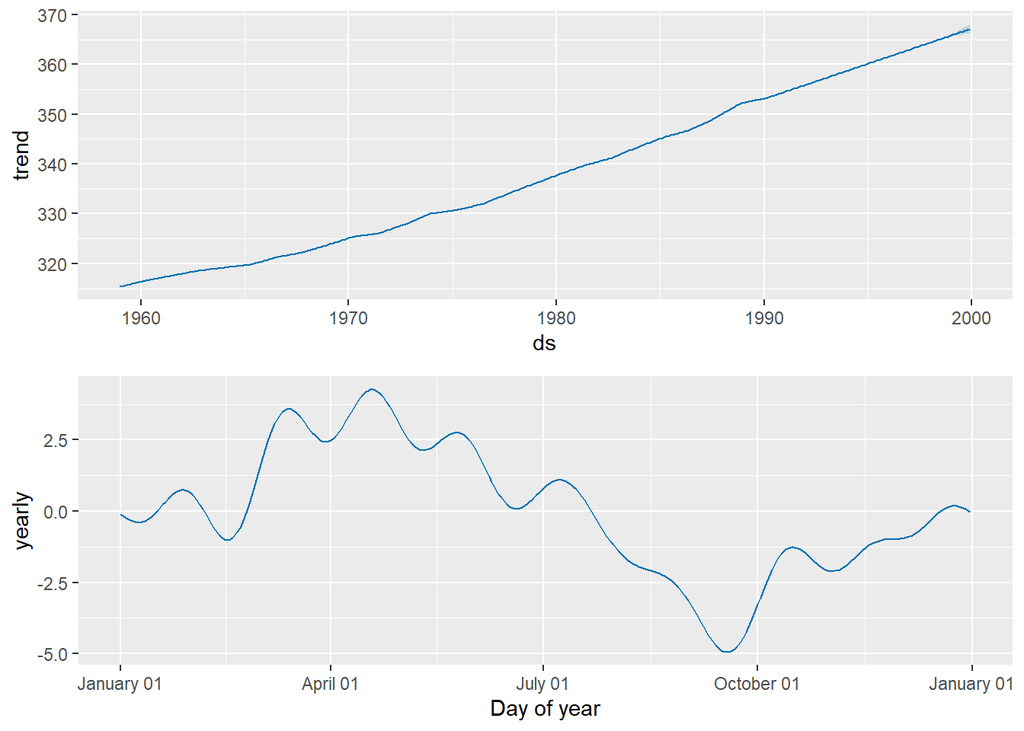

```r
prophet_plot_components(prophet_model, forecast_values)
```

The trend component shows long-run growth in atmospheric CO2 levels. The yearly component shows a clear seasonal pattern with regular peaks and troughs during the year.

# Discussion

This dataset is well suited for Prophet because the main features of the series are easy to identify. The model captures both the upward trend and the yearly seasonal movement.

One advantage of Prophet is that it is straightforward to apply and the output is easy to understand. This is useful when the goal is to communicate the results clearly.

A limitation is that only one main model specification is used here. It could be interesting to compare this forecast with a different Prophet configuration or with another time series method such as ARIMA.

Even so, the current model gives a clear and sensible forecast for this series.

# Conclusion

In this project, I used Meta’s Prophet model to forecast the `co2` time series in R. The data shows a strong upward trend and clear yearly seasonality. The Prophet forecast suggests that `co2` levels will continue to increase over the next two years.

Overall, this project is a simple example of how Prophet can be used to analyse and forecast time series data in an interpretable way.